# Wrangle and Analyze Data - WeRateDogs

#### Relationship between favorites and retweets

```python
import bokeh
from bokeh.models import HoverTool
from bokeh.models import ColumnDataSource
from bokeh.plotting import figure,show,output_notebook
output_notebook()
```

```python
retweets = df['retweet_count']
favorites = df['favorite_count']
```

```python
p1 = figure(height=300,sizing_mode="scale_width",title="Correlation between Retweets and Favorites",toolbar_location="above")
p1.circle(x = retweets,y = favorites,alpha = 0.5,fill_color="limegreen",size = 10)

# Fit Regression line
regression = np.polyfit(retweets, favorites, 1)
r_x, r_y = zip(*((i, i*regression[0] + regression[1]) for i in range(70000)))
p1.line(r_x, r_y, line_color="blue", line_width=2, alpha=0.7, legend="Regression Line")

p1.legend.location = "top_left"
p1.xaxis.axis_label = 'Favorites Count'
p1.yaxis.axis_label = 'Retweets Count'
p1.left[0].formatter.use_scientific = False
show(p1)
```

[interactive chart not shown]

```python
from scipy.stats import linregress
(linregress(retweets, favorites))
```

```
LinregressResult(slope=2.4541638699884065, intercept=2180.6836835642234, rvalue=0.91739947003428024, pvalue=0.0, stderr=0.023859270538077286)
```

> From the above scatter plot and the linear regression output (`rvalue = 0.91` ) we see a very strong positive linear correlation between *retweet count* and *favorites count*.

```python
cols = ['retweet_count','favorite_count','rating_numerator']
df_viz = df[cols].groupby([df['timestamp'].dt.year,df['timestamp'].dt.month]).agg(['median','count'])
df_viz
```

| timestamp | timestamp | retweet_count median | retweet_count count | favorite_count median | favorite_count count | rating_numerator median | rating_numerator count |
| --- | --- | --- | --- | --- | --- | --- | --- |
| 2015 | 11 | 236.0 | 296 | 559.0 | 296 | 10.0 | 296 |
|  | 12 | 688.0 | 367 | 1820.0 | 367 | 10.0 | 367 |
| 2016 | 1 | 925.0 | 169 | 2822.0 | 169 | 10.0 | 169 |
|  | 2 | 1007.0 | 111 | 2910.0 | 111 | 10.0 | 111 |
|  | 3 | 1053.5 | 120 | 3348.0 | 120 | 11.0 | 120 |
|  | 4 | 1392.0 | 54 | 4402.5 | 54 | 11.0 | 54 |
|  | 5 | 1289.0 | 57 | 4279.0 | 57 | 11.0 | 57 |
|  | 6 | 1751.0 | 81 | 5652.0 | 81 | 10.0 | 81 |
|  | 7 | 1774.0 | 88 | 5657.0 | 88 | 11.0 | 88 |
|  | 8 | 1972.0 | 59 | 6969.0 | 59 | 11.0 | 59 |
|  | 9 | 3055.0 | 63 | 9659.0 | 63 | 11.0 | 63 |
|  | 10 | 3200.0 | 65 | 10797.0 | 65 | 12.0 | 65 |
|  | 11 | 2998.0 | 53 | 11081.0 | 53 | 12.0 | 53 |
|  | 12 | 2929.0 | 53 | 11061.0 | 53 | 12.0 | 53 |
| 2017 | 1 | 2962.5 | 66 | 13271.5 | 66 | 12.0 | 66 |
|  | 2 | 3223.0 | 64 | 15269.0 | 64 | 12.0 | 64 |
|  | 3 | 3988.5 | 48 | 19090.5 | 48 | 12.0 | 48 |
|  | 4 | 5007.0 | 41 | 20991.0 | 41 | 12.0 | 41 |
|  | 5 | 5222.0 | 43 | 21120.0 | 43 | 13.0 | 43 |
|  | 6 | 4281.5 | 44 | 23956.0 | 44 | 13.0 | 44 |
|  | 7 | 5459.0 | 49 | 28038.0 | 49 | 13.0 | 49 |
|  | 8 | 7486.5 | 2 | 36147.0 | 2 | 13.0 | 2 |

```python
dfviz_2015 = df_viz['favorite_count'].loc[2015].reset_index()
dfviz_2016 = df_viz['favorite_count'].loc[2016].reset_index()
dfviz_2017 = df_viz['favorite_count'].loc[2017].reset_index()
```

```python
hover = HoverTool(tooltips=[("Month", "@x"),("Median Favorite Count", "@y")])
p = figure(height = 300,sizing_mode  = "scale_width",title="Median Favorite Counts over the Years",tools=[hover,'save'],toolbar_location="above")
# p.circle(x = dfviz_2015['timestamp'].tolist(),y = dfviz_2015['median'].tolist(),size=(dfviz_2015['count'].tolist()),alpha = 0.5,fill_color="lightgreen",legend="2015 Favorite Counts")
p.circle(x = dfviz_2016['timestamp'].tolist(),y = dfviz_2016['median'].tolist(),size=(dfviz_2016['count'].tolist()),alpha = 0.5,fill_color="red",legend="2016 Favorite Counts")
p.circle(x = dfviz_2017['timestamp'].tolist(),y = dfviz_2017['median'].tolist(),size=(dfviz_2017['count'].tolist()),alpha = 0.5,fill_color="lightblue",legend="2017 Favorite Counts")
p.title.align = "center"
p.title.text_color = "black"
p.title.text_font_size = "14px"
p.legend.location = "top_left"
p.xaxis.axis_label = "Months"
p.yaxis.axis_label = "Favorite Counts"
p.xaxis.ticker = [1,2,3,4,5,6,7,8,9,10,11,12]
show(p)
```

[interactive chart not shown]

> The size of circle glyphs indicate the relative no. of tweets in a month. The plot shows year wise, how no. of tweets made decreased and the increase of `favorite count` over time. The popularity of **WeRateDogs** has certainly increased since its [inception](https://en.wikipedia.org/wiki/WeRateDogs) in 2015.

#### Popular Dog Gender

```python
df['dog_gender'].value_counts()
```

```
male      1013
NaN       642
female    338
Name: dog_gender, dtype: int64
```

```python
# get Gender names
gendernames = df['dog_gender'].value_counts().index.tolist()
# get count of Gender
gendercount = df['dog_gender'].value_counts().values.tolist()
```

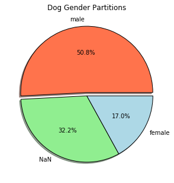

```python
import matplotlib
import matplotlib.pyplot as plt
%matplotlib inline

# Plot the Pie Chart partitioned by dog gender
plt.figure(figsize=(5,5))
colors = ['#ff734c','lightgreen','lightblue']
plt.pie(gendercount, labels=gendernames, autopct='%1.1f%%',shadow=True,colors=colors,radius = 1,explode=(0.05, 0, 0))
plt.title('Dog Gender Partitions')
plt.show()
```

> - Male Dogs appear to be the most popular amongst all the tweets, as 50% of the tweets are about male dogs.
> - About 32% of the tweets did not contain any mention or tags indicating dog gender.

#### Popular Dog Breeds

```python
# Filter dog_breed counts < 15 and create a new dataframe
df_dogbreed = df.loc[df['Is_Dog']==True].groupby(df.dog_breed).filter(lambda x: len(x) >= 15).reset_index(drop=True)
# get names of dog breeds
breednames = df_dogbreed['dog_breed'].value_counts().index.tolist()
# get count of dog breeds
breedcounts = df_dogbreed['dog_breed'].value_counts().values.tolist()
# Construct dataframe of dogbreed counts
df_dogbreed = pd.DataFrame({'Dog_Breed': breednames,'Count': breedcounts})
df_dogbreed
```

|  | Count | Dog_Breed |
| --- | --- | --- |
| 0 | 138 | golden_retriever |
| 1 | 95 | Labrador_retriever |
| 2 | 88 | Pembroke |
| 3 | 79 | Chihuahua |
| 4 | 54 | pug |
| 5 | 41 | chow |
| 6 | 40 | Samoyed |
| 7 | 38 | Pomeranian |
| 8 | 38 | toy_poodle |
| 9 | 29 | malamute |
| 10 | 27 | cocker_spaniel |
| 11 | 26 | French_bulldog |
| 12 | 23 | Chesapeake_Bay_retriever |
| 13 | 22 | miniature_pinscher |
| 14 | 20 | German_shepherd |
| 15 | 20 | Siberian_husky |
| 16 | 19 | Staffordshire_bullterrier |
| 17 | 18 | Maltese_dog |
| 18 | 18 | Eskimo_dog |
| 19 | 18 | Shetland_sheepdog |
| 20 | 17 | Rottweiler |
| 21 | 17 | beagle |
| 22 | 17 | Cardigan |
| 23 | 17 | Shih-Tzu |
| 24 | 16 | Lakeland_terrier |
| 25 | 16 | kuvasz |
| 26 | 16 | Italian_greyhound |

```python
hover_bar = HoverTool(tooltips=[("Count Value", "@right")])
p = figure(y_range=breednames,height = 400,sizing_mode="scale_width",title="Histogram of Dog Breeds",toolbar_location="above")
p.hbar(y=breednames, height=0.5, left=0, right=breedcounts, color="limegreen")
p.add_tools(hover_bar)
p.xaxis.axis_label = "Count"
show(p)
```

[interactive chart not shown]

```python
df[cols].loc[df['Is_Dog']==True].groupby(df['dog_breed']).agg(['mean','median'])
```

| dog_breed | retweet_count mean | retweet_count median | favorite_count mean | favorite_count median | rating_numerator mean | rating_numerator median |
| --- | --- | --- | --- | --- | --- | --- |
| Afghan_hound | 5815.000000 | 5173.0 | 16988.666667 | 16968.0 | 9.666667 | 13.00 |
| Airedale | 1355.250000 | 961.0 | 5182.333333 | 2969.5 | 9.833333 | 10.50 |
| American_Staffordshire_terrier | 2146.923077 | 1648.0 | 7416.769231 | 5808.0 | 11.000000 | 11.00 |
| Appenzeller | 1421.000000 | 1421.0 | 7213.500000 | 7213.5 | 11.000000 | 11.00 |
| Australian_terrier | 3000.000000 | 3000.0 | 10933.500000 | 10933.5 | 9.000000 | 9.00 |
| Bedlington_terrier | 2789.800000 | 2485.0 | 12808.000000 | 13650.0 | 10.000000 | 9.00 |
| Bernese_mountain_dog | 1561.600000 | 1421.0 | 6677.700000 | 4908.0 | 11.200000 | 11.50 |
| Blenheim_spaniel | 2518.100000 | 982.5 | 9119.800000 | 3554.0 | 11.200000 | 11.50 |
| Border_collie | 2153.333333 | 1212.5 | 8772.500000 | 4048.0 | 10.000000 | 11.50 |
| Border_terrier | 3295.428571 | 2292.0 | 13358.285714 | 13224.0 | 12.142857 | 12.00 |
| Boston_bull | 1670.333333 | 871.0 | 6085.222222 | 2861.0 | 9.444444 | 10.00 |
| Brabancon_griffon | 281.333333 | 270.0 | 867.666667 | 972.0 | 10.000000 | 10.00 |
| Brittany_spaniel | 1458.428571 | 654.0 | 5790.142857 | 2619.0 | 10.428571 | 11.00 |
| Cardigan | 4421.823529 | 2744.0 | 15039.000000 | 10412.0 | 11.529412 | 12.00 |
| Chesapeake_Bay_retriever | 2770.565217 | 1779.0 | 10401.826087 | 5650.0 | 10.652174 | 10.00 |
| Chihuahua | 2800.265823 | 924.0 | 8644.113924 | 2854.0 | 10.632911 | 11.00 |
| Dandie_Dinmont | 1006.666667 | 857.0 | 3379.666667 | 2876.0 | 10.666667 | 11.00 |
| Doberman | 1754.750000 | 1536.5 | 8337.125000 | 7425.0 | 11.250000 | 11.00 |
| English_setter | 1465.571429 | 716.0 | 4759.000000 | 1631.0 | 9.857143 | 9.00 |
| English_springer | 5838.777778 | 573.0 | 15406.777778 | 2186.0 | 11.111111 | 11.00 |
| EntleBucher | 685.000000 | 685.0 | 2631.000000 | 2631.0 | 11.000000 | 11.00 |
| Eskimo_dog | 4643.277778 | 1367.0 | 11774.944444 | 5311.0 | 11.777778 | 12.00 |
| French_bulldog | 4735.192308 | 2683.5 | 18384.576923 | 10229.5 | 11.269231 | 12.00 |
| German_shepherd | 2586.450000 | 1837.0 | 9974.800000 | 7014.5 | 11.000000 | 11.50 |
| German_short-haired_pointer | 1425.142857 | 702.0 | 6388.142857 | 2542.0 | 10.428571 | 10.00 |
| Gordon_setter | 2427.500000 | 973.0 | 5423.000000 | 4064.5 | 11.750000 | 12.00 |
| Great_Dane | 1770.555556 | 1300.0 | 6148.111111 | 4396.0 | 11.111111 | 11.00 |
| Great_Pyrenees | 4597.285714 | 1991.5 | 12684.071429 | 6827.0 | 14.928571 | 12.00 |
| Greater_Swiss_Mountain_dog | 2141.333333 | 1663.0 | 10344.666667 | 7585.0 | 11.333333 | 12.00 |
| Ibizan_hound | 421.000000 | 308.0 | 1091.666667 | 779.0 | 9.000000 | 9.00 |
| ... | ... | ... | ... | ... | ... | ... |
| cocker_spaniel | 3628.000000 | 1999.0 | 11490.555556 | 8325.0 | 11.259259 | 11.00 |
| collie | 2203.900000 | 940.0 | 7207.300000 | 3576.5 | 10.800000 | 10.50 |
| curly-coated_retriever | 1179.000000 | 512.0 | 4519.333333 | 1790.0 | 10.333333 | 9.00 |
| dalmatian | 1693.000000 | 1352.5 | 5087.833333 | 4944.5 | 9.333333 | 9.50 |
| flat-coated_retriever | 4413.875000 | 2826.5 | 16523.625000 | 14821.0 | 11.250000 | 12.00 |
| giant_schnauzer | 3723.666667 | 1182.0 | 12198.666667 | 2638.0 | 12.000000 | 13.00 |
| golden_retriever | 3575.202899 | 2223.0 | 12183.101449 | 7990.0 | 13.250000 | 12.00 |
| groenendael | 407.000000 | 407.0 | 1857.000000 | 1857.0 | 10.000000 | 10.00 |
| keeshond | 1685.500000 | 1436.0 | 4823.000000 | 4689.5 | 10.250000 | 10.00 |
| kelpie | 2409.363636 | 2391.0 | 9808.090909 | 9349.0 | 11.454545 | 11.00 |
| komondor | 2028.333333 | 2034.0 | 9796.666667 | 7890.0 | 11.000000 | 11.00 |
| kuvasz | 1707.625000 | 1672.0 | 5726.875000 | 5042.0 | 11.141250 | 11.63 |
| malamute | 2511.137931 | 2120.0 | 8653.172414 | 6892.0 | 10.896552 | 11.00 |
| malinois | 1179.444444 | 1284.0 | 4054.555556 | 2979.0 | 10.666667 | 10.00 |
| miniature_pinscher | 2377.772727 | 1507.0 | 8572.727273 | 3945.0 | 10.590909 | 11.00 |
| miniature_poodle | 948.500000 | 835.5 | 3396.500000 | 2362.5 | 9.875000 | 10.00 |
| miniature_schnauzer | 1063.250000 | 716.0 | 4049.500000 | 1832.5 | 9.250000 | 10.00 |
| papillon | 1266.000000 | 772.0 | 4317.714286 | 2829.0 | 10.000000 | 11.00 |
| pug | 1790.555556 | 963.0 | 5822.814815 | 2586.0 | 10.240741 | 10.00 |
| redbone | 1086.333333 | 643.5 | 3230.666667 | 2755.5 | 9.666667 | 10.00 |
| schipperke | 2114.444444 | 2007.0 | 7293.000000 | 4638.0 | 10.777778 | 11.00 |
| silky_terrier | 1836.000000 | 1836.0 | 7196.000000 | 7196.0 | 12.000000 | 12.00 |
| soft-coated_wheaten_terrier | 792.545455 | 666.0 | 2237.727273 | 2011.0 | 25.454545 | 10.00 |
| standard_poodle | 6465.571429 | 873.0 | 15534.285714 | 2935.0 | 10.285714 | 10.00 |
| standard_schnauzer | 901.000000 | 901.0 | 1999.000000 | 1999.0 | 12.000000 | 12.00 |
| toy_poodle | 2396.078947 | 1093.0 | 6518.157895 | 3996.5 | 11.105263 | 11.00 |
| toy_terrier | 1122.000000 | 1122.0 | 4411.000000 | 4411.0 | 11.000000 | 11.00 |
| vizsla | 1942.923077 | 1623.0 | 7362.615385 | 5652.0 | 10.846154 | 11.00 |
| whippet | 2301.777778 | 2132.0 | 8573.444444 | 6276.0 | 10.444444 | 10.00 |
| wire-haired_fox_terrier | 2844.500000 | 2844.5 | 8368.000000 | 8368.0 | 11.500000 | 11.50 |

111 rows × 6 columns

> The most popular dog breeds appear to *Golden Retriever* and *Labrador Retriever*.